# Comparing 2+ Means using One-Way ANOVA

Day 24

Claire Kelling

Carleton College  
STAT 120 - Fall 2026

## Question of the Day

Do you have a pet peeve?

## Today’s Topics

Housekeeping

- EDA questions?
- Study guide posted!
- Trouble communicating with partners?
- Cite your data in your EDA!

Topics covered today:

- Comparing $2+$ Means using One-Way ANOVA (Section 8.1)

# Background

## Inference Tools (Classical Methods)

**Categorical Response**

1. One Proportion: 1 sample z test/CI
2. Difference in Two Proportions: 2 sample z test/CI OR chi-square test
3. More than two levels: GOF chi-square test
4. Association between 2 categorical variables: chi-square association test

**Quantitative Response (assuming we don’t know $\sigma$)**

1. One mean: 1 sample t test/CI
2. Difference in 2 means: 2 independent sample t test/CI OR matched pairs
3. Compare $>2$ means: one-way ANOVA

## Multiple Categories

- We have already covered inference for a difference in means IF the categorical variable has only **two categories** (i.e. compare two groups)
- Today: how to assess statistical discernibility for differences in means across **two or more categories** (i.e. compare more than two groups)

## Hypotheses

**ANOVA Hypotheses**

To test for a difference in true/population means across k groups:

$$H_0: \mu_1 = \mu_2 = ... = \mu_k$$

$$H_a:\text{ At least one } \mu_i \neq \mu_j$$

# Frisbee Example

## Frisbee Example

Does Frisbee grip affect the distance of a throw?

A student performed the following experiment:

- 3 grips, 8 throws using each grip
- 3 grips: normal, one finger out, frisbee inverted
- A grip type is randomly assigned to each of the 24 throws she plans on making
- Response: measured in paces, how far her throw went

**Question (Your Turn)**

Is this evidence that grip affects mean distance thrown? State the ANOVA hypotheses.

## Frisbee Example

$H_0: \mu_1 = \mu_2 = \mu_3$

$H_a$: at least one $\mu_1, \mu_2, \mu_3$ is not the same

**Exploratory Data Analysis:**

|  | FingerOut | Inv | Norm |
| --- | --- | --- | --- |
| n | 8 | 8 | 8 |
| Mean | 29.5 | 32.4 | 33.1 |
| SD | 4.17 | 3.16 | 3.94 |

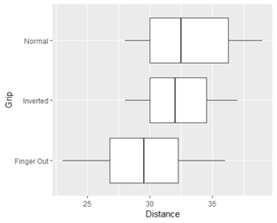

## Difference Between 2+ Means

Whether or not two or more means are significantly different depends on

1. How far apart the means are
2. How much variability there is within each group
3. Sample sizes within each group

## Within vs Between Group Variation

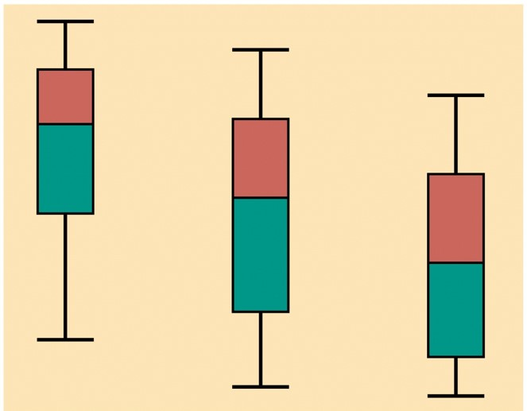

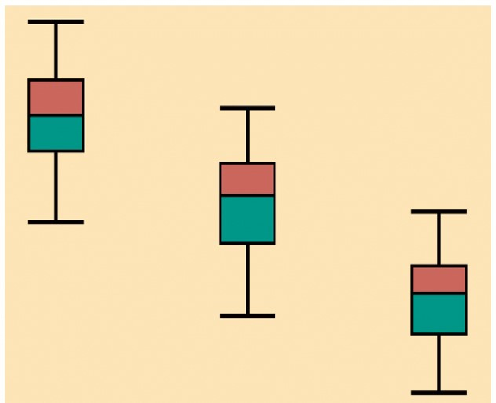

- Both data sets 1 and 2 have the same BETWEEN group variation
- Data set 1 has larger WITHIN group variation than data
- **Left:** Means are not significantly different.
- **Right:** Means are significantly different

# ANOVA

## Analysis of Variance

**ANOVA**

**Analysis of Variance** (ANOVA): compares the variability between groups to the variability within groups

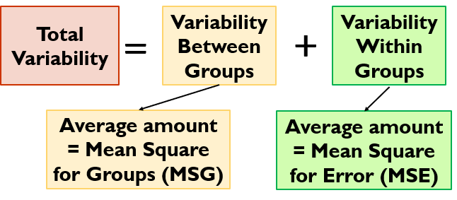

## F-Statistic

The **F-statistic** is a ratio:

$$F = \frac{\color{mediumpurple}{MSG}}{\color{mediumpurple}{MSE}} = \frac{\text{avg between group variability}}{\text{avg within group variability}}$$

If there really is a difference between the groups ($H_a$ true), we would expect the F-statistic to be

1. Large positive
2. Large negative
3. Close to 0

Large Positive: If there is a difference, we expect the between group variability to be higher than within group variability.

Again, this is always a **right tailed** test!

## Frisbee Example

**R Code**

```r
frisbee_anova <- aov(Distance ~ Grip, data = frisbee)

summary(frisbee_anova)
##            Df Sum Sq  Mean Sq  F value  Pr(>F)
## Grip         2  58.58   29.29    2.045   0.154
## Residuals   21 300.75   14.32
```

- F test statistic: 2.045
- P-value: 0.154

## Frisbee Example: Inference

**Hypotheses**

Hypotheses for One-way ANOVA:

- $H_0: \mu_1 = \mu_2 = \mu_3$
- $H_a$: at least one of $\mu_1, \mu_2, \mu_3$ is not the same
- $\mu_i$ is the true mean distance thrown using grip $i$

**From Data**

- **F** = 2.05 (df = 2, 21), **P-value** = 0.154

**Conclusion**

- **Do not reject the null hypothesis.** The difference in observed means is not statistically discernible.
- About 15% of the time we would see the grip differences like those observed, or even bigger, when there is actually **no difference** between the true mean distances thrown with different grips.

# P-value Calculation

## P-value

We have a test statistic. What else do we need to perform the hypothesis test?

- A distribution of the test statistic assuming $H_0$ is true
- Can then find the p-value

Once again, we have two choices:

1. Simulation
2. Theory

## F Distribution

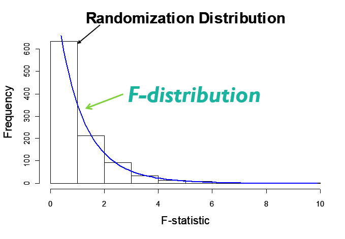

## F Distribution

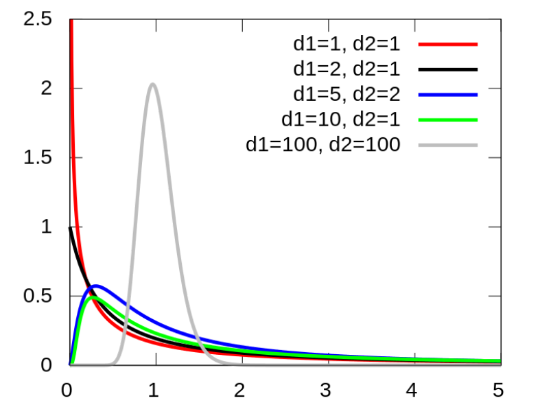

## F Distribution Conditions

We can use the F Distribution to generate a p-value if:

- Sample sizes in each group are large (each $n_i \geq 30$) OR the data within each group are relatively normally distributed
- Variability is similar in all groups$^*$
- The F-distribution has **two** degrees of freedom, one for the numerator of the ratio $(k - 1)$ and one for the denominator $(n - k)$
- For F-statistics, the p-value (the area as extreme or more extreme) is always the **right tail**

## Simulation

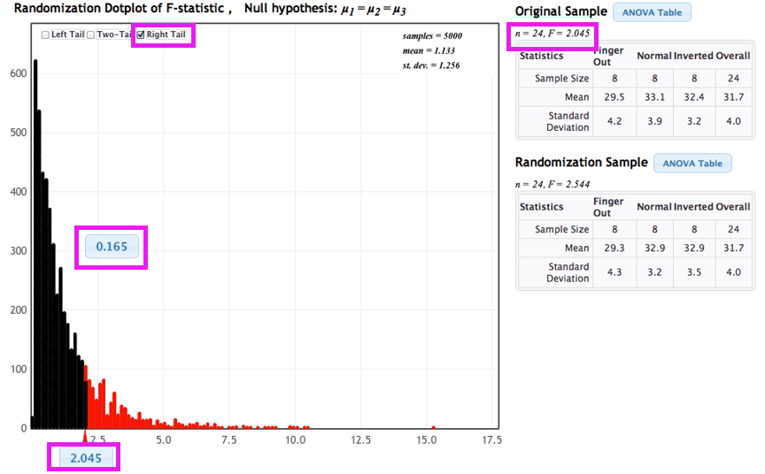

- An F-statistic as large as 2.045 would occur by chance about 16% of the time if the means were all equal.
- Our results are inconclusive and do not support the claim that grips affect average distance.

## Theoretical F Distribution

[figure not shown]

**In R**

```r
1 - pf(2.045, 2, 21)
```

```
[1] 0.1543639
```

## Check Assumptions

**Large Sample Size OR Normality**

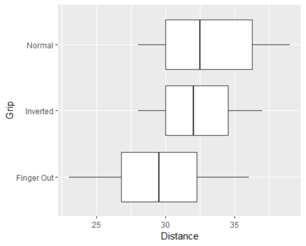

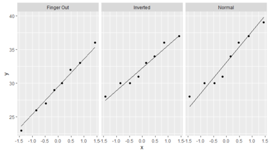

```r
## Grip        mean     sd    n
## Finger Out  29.5     4.17  8
## Inverted    32.4     3.16  8
## Normal      33.1     3.94  8
```

**Takeaway**: Small $n_i$ but all groups are roughly normal

## Check Assumptions: Equal Variance

**Equal Variance**

- The F-distribution assumes equal within group variability for each group*
  - *This is also an assumption when using the randomization distribution
- As a rough rule of thumb, this assumption is violated if the largest group standard deviation is **more than double** the smallest group standard deviation

**Frisbee Example**

Equal Variances: yes, rule of thumb is not violated

## Picturing Variation

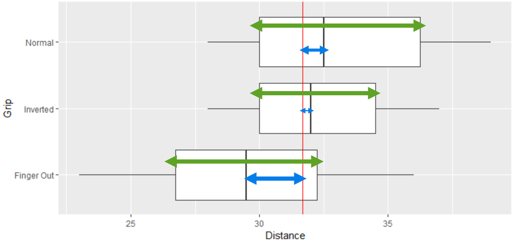

- Green: variation within groups
- Blue: variation between groups (overall mean is 31.7)

## Sum of Squares

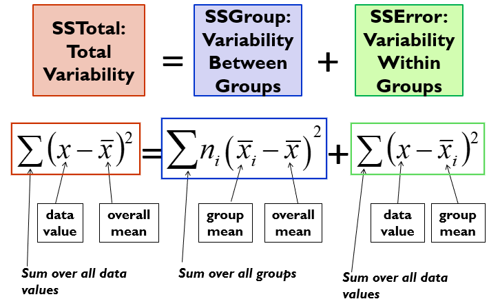

## Sum of Squares: Frisbee Data

SSG = $\sum n_i (\bar{x}_i - \bar{x})^2 = 58.58333$  
+ SSE = $\sum (x - \bar{x}_i)^2 = 300.7500$

= SSTotal = $\sum(x - \bar{x})^2 = 359.333$

(Note SSE > SSG)

## ANOVA Table for Frisbee Data

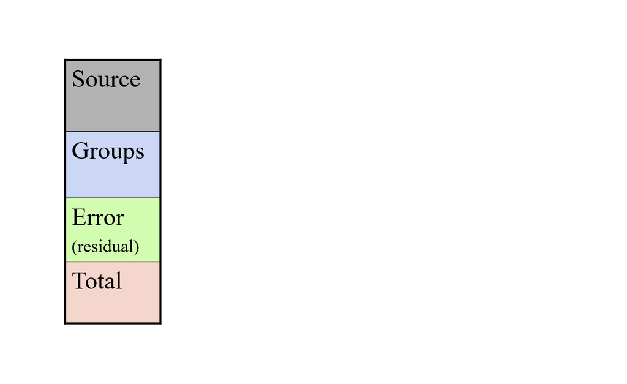

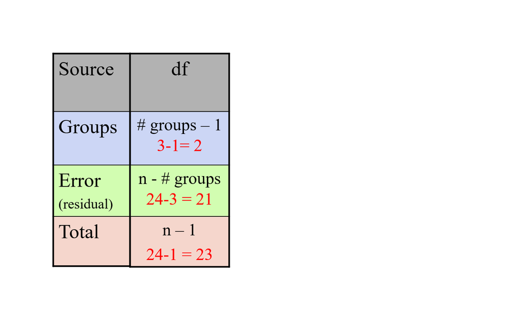

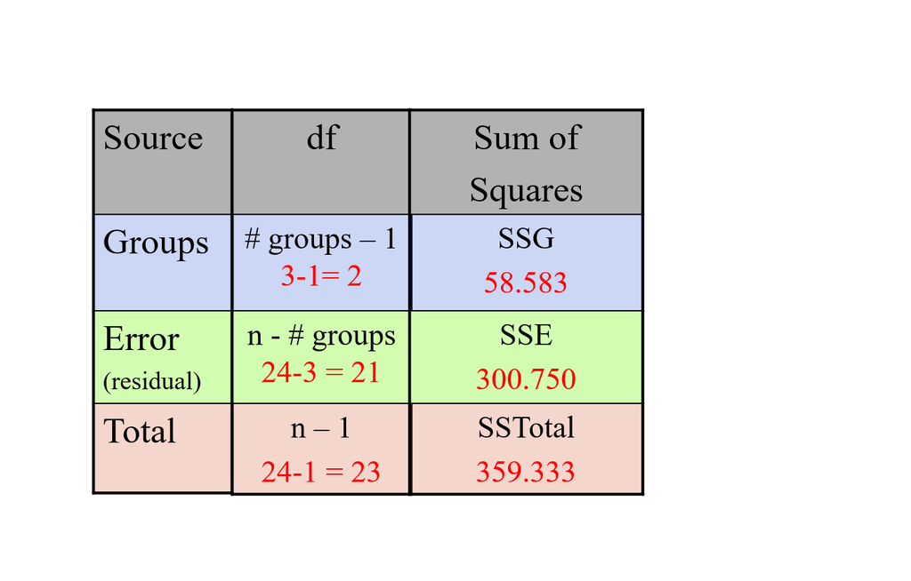

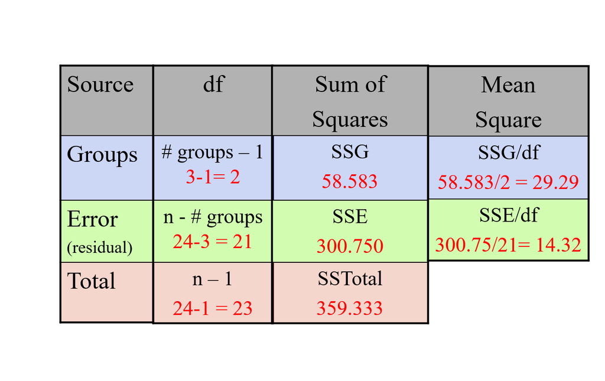

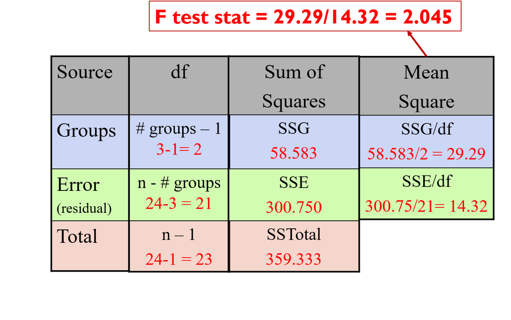

## ANOVA in R

Let’s conduct ANOVA for comparing mean distance for the frisbee grip types:

```r
frisbee_anova <- aov(Distance ~ Grip, data = frisbee)

summary(frisbee_anova)
##            Df   Sum Sq   Mean Sq   F value   Pr(>F)
## Grip        2    58.58      29.29    2.045   0.154
## Residuals  21   300.75      14.32
```

- F Test Statistic: 2.045
- P-value: 0.154

## Handout

Work through Example 1 on the handout!

One RStudio open per group!

## Next Class

Finish up ANOVA, Multiple Regression